# Chapter 3 - Tidying Data with `tidyr`

Tidy data:

> Tidy data is a standard way of mapping the meaning of a dataset to its structure. A dataset is messy or tidy depending onhow rows, columns, and tables are matched up with observations, variables and types.

Resuming: Tidy data means that i can plot or summarize the data efficiently.

Example:

```r
library("magrittr")
library("dplyr")
library("ggplot2")
iris %>% select(Species, Petal.Length) %>% head(3)
```

```
##   Species Petal.Length
## 1  setosa          1.4
## 2  setosa          1.4
## 3  setosa          1.3
```

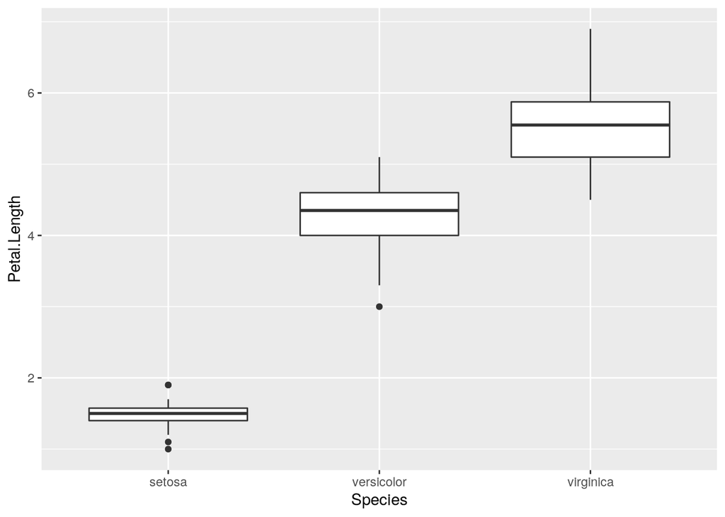

```r
iris %>% select(Species, Petal.Length) %>%
    qplot(Species, Petal.Length, geom = "boxplot", data = .)
```

This works because i have a column for th x-axis and another for the y-axis. But what happens if i want to plot the different measurements of the irises to see how those are? Each measurement is a separate column. They are Petal.length, Petal.Width, and so on. The ``tidyr` package adresses that.

```r
# install.packages("tidyr")
library("tidyr")
```

It has a function `gather()`, that modifies the data frame so columns become names in a factor and other columns become values. What it does is essentially tranform the data frame so that you get one column containing the name of your original columns and another column containing values in those columns.

```r
iris %>%
    gather(key = Attribute, value = Measurement,
           Sepal.Length, Sepal.Width) %>%
    select(Species, Attribute, Measurement) %>%
    head(3)
```

```
##   Species    Attribute Measurement
## 1  setosa Sepal.Length         5.1
## 2  setosa Sepal.Length         4.9
## 3  setosa Sepal.Length         4.7
```

This code tells `gather()` to make a column called *Attributes* that contains the names of columns from the input data frame and another called *Measurement* that will contain the values of the key columns. From the resulting data frame, you can see that the *Attribute* column contains the Sepal.Length and Sepal.Width names, and another column that shows the *Measurements*. This transforms the data into a form where we can plot the attributes against measurements.

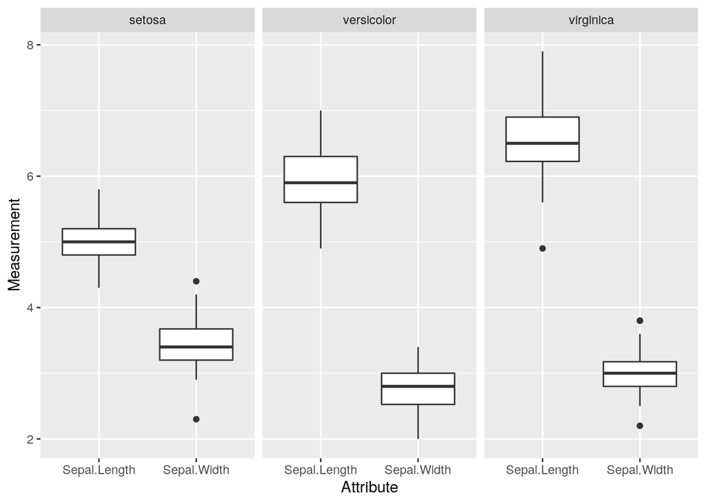

```r
iris %>%
    gather(key = Attribute, value = Measurement,
           Sepal.Length, Sepal.Width) %>%
    select(Species, Attribute, Measurement) %>%
    qplot(Attribute, Measurement, geom = "boxplot", facets = . ~ Species, data = .)
```